# PM566 Midterm Project

Carmen Jiawen Chen

10/20/2021

**Vaccination rates and COVID-19 cases and deaths in California**

**Introduction**

The vaccinations have begun almost a year since its distribution. The fully vaccinated percentage in California was increasing and stagnated around 60%. However, the herd immunity didn’t seem to be achieved and the COVID-19 daily new cases is still very high in California. Therefore, this project aims to investigate the relationship of vaccination rates on COVID-19 daily new cases and deaths in California by using the data from California Health & Human Services Agency and US Center for Disease Control and Prevention.

**Methods**

Data of COVID-19 cases and vaccination rates were acquired from California Health & Human Services Agency and US Center for Disease Control and Prevention, respectively. Data in California and with variables of interest (i.e., date, percentage of first dose, percentage of second dose, daily new cases, cumulative cases, daily new deaths, and cumulative deaths) were extracted. The date variables were formatted in both datasets.

```r
cases <- read.csv("Cases.csv")
vaccinations <- read.csv("Vaccinations.csv")
```

```r
#subset the data
vaccinations <- vaccinations[vaccinations$Location == "CA",]
vaccinations <- vaccinations[, c("Date", "Administered_Dose1_Pop_Pct", "Series_Complete_Pop_Pct")]
cases <- cases[cases$area == "California",]
cases <- cases[, c("date", "cases", "cumulative_cases", "deaths", "cumulative_deaths")]
#rename the data
vaccinations <- rename(vaccinations, date = Date, dose1 = Administered_Dose1_Pop_Pct, dose2 = Series_Complete_Pop_Pct)
#format date
vaccinations$date <- as.Date(vaccinations$date, format = "%m/%d/%Y")
cases$date <- as.Date(cases$date, format = "%Y-%m-%d")
```

Dimensions, headers, and footers of the two datasets were checked. There are 311 observations and 3 variables in the “vaccinations” dataset, as well as 628 observations and 5 variables in the “cases” dataset. Implausible data (e.g., 0 cases increase) was found in the date variable on “2021-10-20” in the “cases” dataset. Considering the 14-day incubation period of the COVID-19 disease, the data from 2021-10-06 to 2021-10-20 were not the final accurate number of cases and deaths since there are still many cases and deaths were not reported timely. Thus, these data were removed from the “cases” dataset.

```r
#check the date
summary(vaccinations$date)
summary(cases$date)
#check for missing value
cases[!complete.cases(cases),]
vaccinations[!complete.cases(vaccinations),]
#remove rows with missing value
cases <- cases[complete.cases(cases),]
#check the dimensions, headers, footers
dim(vaccinations)
dim(cases)
head(vaccinations)
cases <- cases[order(cases$date, decreasing = TRUE),]
head(cases)
tail(vaccinations)
tail(cases)
#remove the data from 2021-10-06 to 2021-10-20
cases <- cases[!(cases$date >= "2021-10-06"),]
#take a look at the variables
str(vaccinations)
summary(vaccinations$dose1)
summary(vaccinations$dose2)
str(cases)
summary(cases$cases)
summary(cases$cumulative_cases)
summary(cases$deaths)
summary(cases$cumulative_deaths)
```

The two datasets were merged into one dataset by date variable. Final dataset has 296 observations and 7 variables. Exploratory data analysis was conducted in the merged dataset. No missing value, implaussible vaule or data error was found. The data includes COVID-19 partial and fully vaccination rates, daily new cases, cumulative cases, daily new deaths, as well cumulative deaths from 2020/12/14 to 2021/10/05. Both univariate and bivariate summary statistics was analyzed. Exploratory graphs were generated between vaccination rates and cases and deaths.

```r
#combine the dataset
covid <- merge(vaccinations, cases, by = "date")
#exploratory analysis
dim(covid)
head(covid)
tail(covid)
str(covid)
summary(covid$date)
summary(covid$dose1)
summary(covid$dose2)
summary(covid$cases)
summary(covid$cumulative_cases)
summary(covid$deaths)
summary(covid$cumulative_cases)
covid[!complete.cases(covid),]
```

**Preliminary Results**

```r
#Table 1. Characteristics of the COVID-19 data
covid %>%
  select("Date" = date,
         "First dose, %" = dose1,
         "Second dose, %" = dose2,
         "Daily new cases" = cases,
         "Cumulative cases" = cumulative_cases,
         "Daily new deaths" = deaths,
         "Cumulative deaths" = cumulative_deaths) %>%
  tbl_summary() %>%
  modify_caption ("**Table 1. Characteristics of the COVID-19 data**")
```

**Table 1. Characteristics of the COVID-19 data**

| **Characteristic** | **N = 296**<sup>1</sup> |
| --- | --- |
| Date | 2020-12-14 to 2021-10-05 |
| First dose, % | 52 (15, 64) |
| Second dose, % | 36 (0, 52) |
| Daily new cases | 4,275 (1,810, 11,520) |
| Cumulative cases | 3,669,089 (3,512,726, 3,833,183) |
| Daily new deaths | 64 (23, 159) |
| Cumulative deaths | 62,710 (58,891, 63,905) |

<sup>*1*</sup> Range; Median (IQR)

Table 2 presented the correlation coefficients of vaccination rates with daily new cases and deaths. Vaccination rates were negatively associated with daily new cases and deaths. Such negative association was stronger in the correlation between vaccination rates and daily new deaths (R: -0.78 for first dose, -0.68 for second dose).

```r
#First dose correlation
Cases = cor(covid$dose1, covid$cases, use = "complete")
Deaths = cor(covid$dose1, covid$deaths, use = "complete")
`First dose` = rbind(Cases, Deaths)
colnames(`First dose`) <- "First dose"
#Second dose correlation
Cases = cor(covid$dose2, covid$cases, use = "complete")
Deaths = cor(covid$dose2, covid$deaths, use = "complete")
`Second dose` = rbind(Cases, Deaths)
colnames(`Second dose`) <- "Second dose"
#Combine the table
cbind(`First dose`, `Second dose`) %>%
  knitr::kable(caption = "<strong>Table 2. Correlation coefficients of vacciantion rates and cases/deaths</strong>")
```

**Table 2. Correlation coefficients of vacciantion rates and cases/deaths**

|  | First dose | Second dose |
| --- | --- | --- |
| Cases | -0.4990338 | -0.3931054 |
| Deaths | -0.7814445 | -0.6816794 |

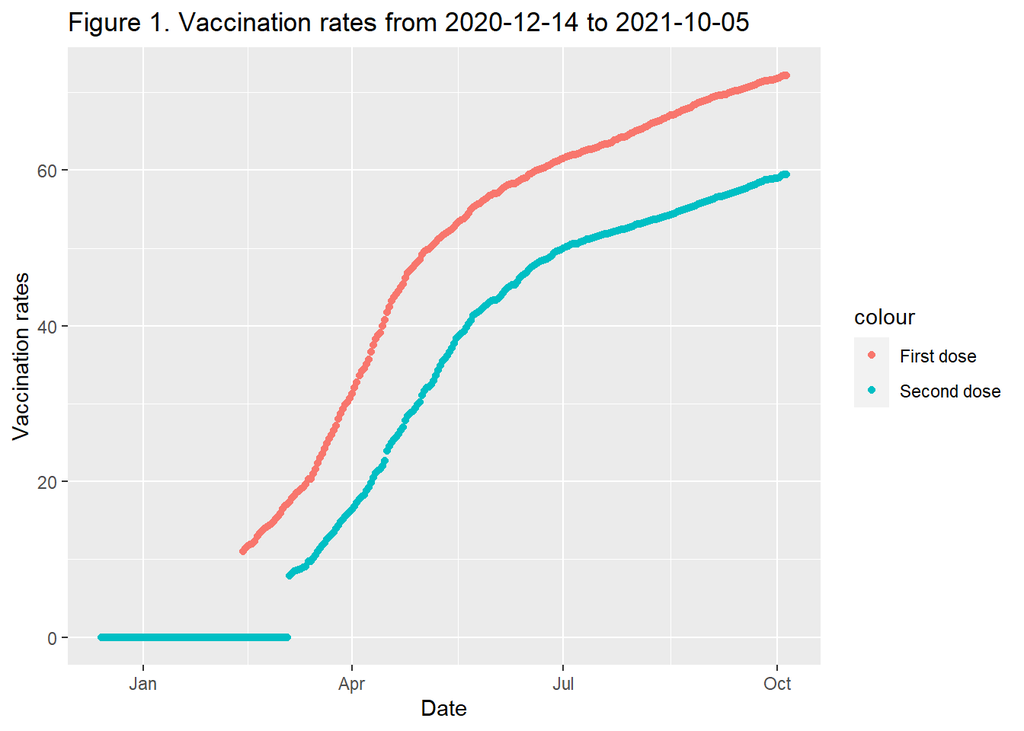

```r
#Vaccination rates
ggplot(data = covid) +
  geom_point(mapping = aes(x = date, y = dose1, color = "First dose")) +
  geom_point(mapping = aes(x = date, y = dose2, color = "Second dose")) +
  labs(title = "Figure 1. Vaccination rates from 2020-12-14 to 2021-10-05") +
  labs(x = "Date", y = "Vaccination rates")
```

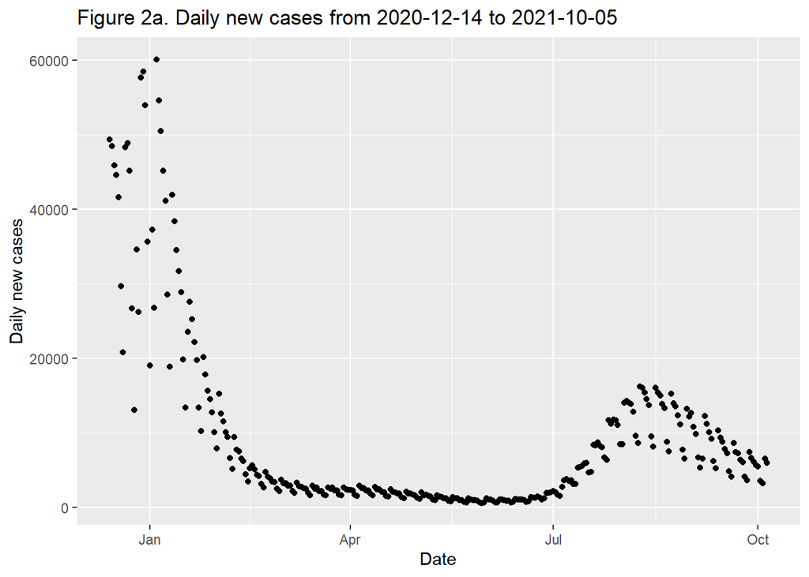

```r
#Cases
ggplot(data = covid) +
  geom_point(mapping = aes(x = date, y = cases)) +
  labs(title = "Figure 2a. Daily new cases from 2020-12-14 to 2021-10-05") +
  labs(x = "Date", y = "Daily new cases")
```

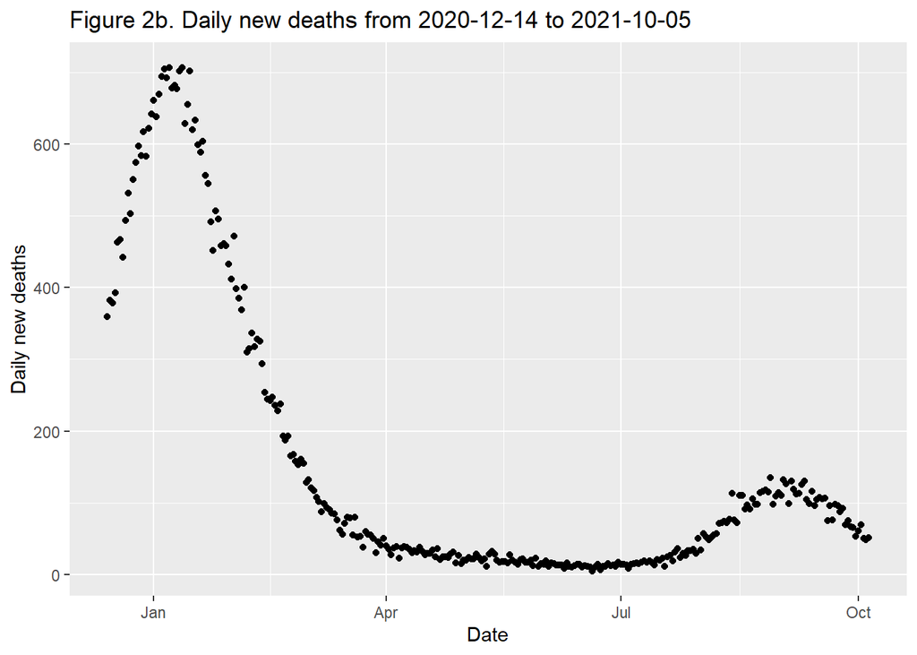

```r
#Deaths
ggplot(data = covid) +
  geom_point(mapping = aes(x = date, y = deaths)) +
  labs(title = "Figure 2b. Daily new deaths from 2020-12-14 to 2021-10-05") +
  labs(x = "Date", y = "Daily new deaths")
```

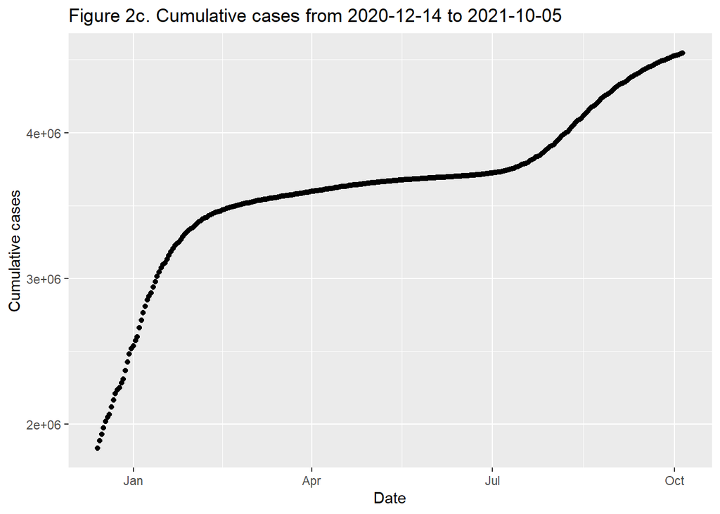

```r
#Cumulative cases
ggplot(data = covid) +
  geom_point(mapping = aes(x = date, y = cumulative_cases)) +
  labs(title = "Figure 2c. Cumulative cases from 2020-12-14 to 2021-10-05") +
  labs(x = "Date", y = "Cumulative cases")
```